# Estimate model pollution and financial dependency with city mandate

# Objective(s)

**Business needs**

Estimate the SO2 emission as a function of financial ratio, policy mandate and a time break

**Description**

**Objective**

Test only with financial ratio computed at the industry level → more observation

**Tables**

1. Table 1: Baseline estimate, SO2 emission reduction and industry financial ratio

**Cautious**

# Metadata

- Key: nii81ldai42313s
- Parent key (for update parent):
- Notebook US Parent (i.e the one to update):
- Epic: Epic 2
- US: US 1
- Date Begin: 11/28/2020
- Duration Task: 1
- Description: Estimate the SO2 emission as a function of financial ratio, policy mandate and a time break
- Step type: Evaluate model
- Status: Active
- Source URL: US 01 Baseline financial ratio
- Task type: Jupyter Notebook
- Users: Thomas Pernet
- Watchers: Thomas Pernet
- User Account: https://468786073381.signin.aws.amazon.com/console
- Estimated Log points: 7
- Task tag: #econometrics,#financial-ratio,#policy,#so2
- Toggl Tag: #model-estimate
- current nb commits: 0
- Meetings:
- Presentation:
- Email Information:
  - thread: Number of threads: 0(Default 0, to avoid display email)

# Input Cloud Storage [AWS/GCP]

## Table/file

- Origin:
- Athena
- Name:
- asif_city_industry_financial_ratio
- Github:
  - https://github.com/thomaspernet/Financial_dependency_pollution/blob/master/01_data_preprocessing/02_transform_tables/00_asif_financial_ratio.md

# Load tables

Since we load the data as a Pandas DataFrame, we want to pass the `dtypes`. We load the schema from Glue to guess the types

|  | Name | Type | Comment |
| --- | --- | --- | --- |
| 0 | year | string | year from 2001 to 2007 |
| 1 | period | string | False if year before 2005 included, True if year 2006 and 2007 |
| 2 | provinces | string |  |
| 3 | cityen | string |  |
| 4 | geocode4_corr | string |  |
| 5 | tcz | string | Two control zone policy city |
| 6 | spz | string | Special policy zone policy city |
| 7 | ind2 | string | 2 digits industry |
| 8 | short | string |  |
| 9 | polluted_di | varchar(5) | Sectors with values above Yearly 75th percentile of SO2 label as ABOVE else BELOW |
| 10 | polluted_mi | varchar(5) | Sectors with values above Yearly average of SO2 label as ABOVE else BELOW |
| 11 | polluted_mei | varchar(5) | Sectors with values above Yearly median of SO2 label as ABOVE else BELOW |
| 12 | polluted_thre | varchar(5) | Sectors with values above 68070.78 of SO2 label as ABOVE else BELOW |
| 13 | tso2 | int | Total so2 city sector |
| 14 | so2_intensity | decimal(21,5) | SO2 divided by output |
| 15 | tso2_mandate_c | float | city reduction mandate in tonnes |
| 16 | in_10_000_tonnes | float | city reduction mandate in 10k tonnes |
| 17 | output | decimal(16,5) | Output |
| 18 | employment | decimal(16,5) | Employemnt |
| 19 | sales | decimal(16,5) | Sales |
| 20 | capital | decimal(16,5) | Capital |
| 21 | working_capital_cit | decimal(16,5) | Inventory [存货 (c81)] + Accounts receivable [应收帐款 (c80)] - Accounts payable [应付帐款 (c96)] city industry year. Scaled by a factor of 10000 |
| 22 | working_capital_ci | decimal(16,5) | Inventory [存货 (c81)] + Accounts receivable [应收帐款 (c80)] - Accounts payable [应付帐款 (c96)] city industry. Scaled by a factor of 100000 |
| 23 | working_capital_i | decimal(16,5) | Inventory [存货 (c81)] + Accounts receivable [应收帐款 (c80)] - Accounts payable [应付帐款 (c96)] industry. Scaled by a factor of 1000000 |
| 24 | asset_tangibility_cit | decimal(16,5) | Total fixed assets [固定资产合计 (c85)] - Intangible assets [无形资产 (c91)] city industry year. Scaled by a factor of 10000 |
| 25 | asset_tangibility_ci | decimal(16,5) | Total fixed assets [固定资产合计 (c85)] - Intangible assets [无形资产 (c91)] city industry. Scaled by a factor of 100000 |
| 26 | asset_tangibility_i | decimal(16,5) | Total fixed assets [固定资产合计 (c85)] - Intangible assets [无形资产 (c91)] industry. Scaled by a factor of 1000000 |
| 27 | current_ratio_cit | decimal(21,5) | Current asset [cuasset] / Current liabilities [c95] city industry year |
| 28 | current_ratio_ci | decimal(21,5) | Current asset [cuasset] / Current liabilities [c95] city industry |
| 29 | current_ratio_i | decimal(21,5) | Current asset [cuasset] / Current liabilities [c95] industry |
| 30 | cash_assets_cit | decimal(21,5) | Cash [( 其中：短期投资 (c79) + 应收帐款 (c80) + 存货 (c81)) - cuasset)] / Assets [其中：短期投资 (c79) + 应收帐款 (c80) + 存货 (c81)] city industry year |
| 31 | cash_assets_ci | decimal(21,5) | Cash [( 其中：短期投资 (c79) + 应收帐款 (c80) + 存货 (c81)) - cuasset)] / Assets [其中：短期投资 (c79) + 应收帐款 (c80) + 存货 (c81)] city industry |
| 32 | cash_assets_i | decimal(21,5) | Cash [( 其中：短期投资 (c79) + 应收帐款 (c80) + 存货 (c81)) - cuasset)] / Assets [其中：短期投资 (c79) + 应收帐款 (c80) + 存货 (c81)] industry |
| 33 | liabilities_assets_cit | decimal(21,5) | Liabilities [(流动负债合计 (c95) + 长期负债合计 (c97))] / Total assets [资产总计318 (c93)] city industry year |
| 34 | liabilities_assets_ci | decimal(21,5) | Liabilities [(流动负债合计 (c95) + 长期负债合计 (c97))] / Total assets [资产总计318 (c93)] city industry |
| 35 | liabilities_assets_i | decimal(21,5) | Liabilities [(流动负债合计 (c95) + 长期负债合计 (c97))] / Total assets [资产总计318 (c93)] industry |
| 36 | return_on_asset_cit | decimal(21,5) | Total annual revenue [全年营业收入合计 (c64) ] / (Delta Total assets 318 [$\Delta$ 资产总计318 (c98)]/2) city industry year |
| 37 | return_on_asset_ci | decimal(21,5) | Total annual revenue [全年营业收入合计 (c64) ] / (Delta Total assets 318 [$\Delta$ 资产总计318 (c98)]/2) city industry |
| 38 | return_on_asset_i | decimal(21,5) | Total annual revenue [全年营业收入合计 (c64) ] / (Delta Total assets 318 [$\Delta$ 资产总计318 (c98)]/2) industry |
| 39 | sales_assets_cit | decimal(21,5) | (Total annual revenue - Income tax payable) [(全年营业收入合计 (c64) - 应交所得税 (c134))] / Total assets [资产总计318 (c98)] city industry year |
| 40 | sales_assets_ci | decimal(21,5) | (Total annual revenue - Income tax payable) [(全年营业收入合计 (c64) - 应交所得税 (c134))] / Total assets [资产总计318 (c98)] city industry |
| 41 | sales_assets_i | decimal(21,5) | (Total annual revenue - Income tax payable) [(全年营业收入合计 (c64) - 应交所得税 (c134))] / Total assets [资产总计318 (c98)] industry |
| 42 | lower_location | string | Location city. one of Coastal, Central, Northwest, Northeast, Southwest |
| 43 | larger_location | string | Location city. one of Eastern, Central, Western |
| 44 | coastal | string | City is bordered by sea or not |
| 45 | fe_c_i | bigint | City industry fixed effect |
| 46 | fe_t_i | bigint | year industry fixed effect |
| 47 | fe_c_t | bigint | city industry fixed effect |

## Schema Latex table

To rename a variable, please use the following template:

```
{
    'old':'XX',
    'new':'XX_1'
    }
```

if you need to pass a latex format with `\`, you need to duplicate it for instance, `\text` becomes `\text:

```
{
    'old':'working\_capital\_i',
    'new':'\\text{working capital}_i'
    }
```

Then add it to the key `to_rename`

[output not shown]

A tibble: 6 × 48

| year <dbl> | period <fct> | provinces <fct> | cityen <fct> | geocode4_corr <dbl> | tcz <dbl> | spz <dbl> | ind2 <dbl> | short <fct> | polluted_di <fct> | ⋯ | return_on_asset_i <dbl> | sales_assets_cit <dbl> | sales_assets_ci <dbl> | sales_assets_i <dbl> | lower_location <fct> | larger_location <fct> | coastal <fct> | fe_c_i <fct> | fe_t_i <fct> | fe_c_t <fct> |
| --- | --- | --- | --- | --- | --- | --- | --- | --- | --- | --- | --- | --- | --- | --- | --- | --- | --- | --- | --- | --- |
| 2003 | FALSE | Shanxi | Changzhi | 1404 | 0 | 0 | 31 | Non-metallic Products | ABOVE | ⋯ | 1.61815 | -8.37127 | 1.11872 | 51.73084 | Central | Central | No | 419 | 78 | 115 |
| 2004 | FALSE | Shanxi | Changzhi | 1404 | 0 | 0 | 15 | Beverages | BELOW | ⋯ | 1.84463 | -13.95399 | -7.87581 | 81.12161 | Central | Central | No | 409 | 92 | 116 |
| 2004 | FALSE | Shanxi | Changzhi | 1404 | 0 | 0 | 24 | Education and Sport Activity" | BELOW | ⋯ | 7.26719 | 20.39495 | 94.10156 | -19.46074 | Central | Central | No | 414 | 101 | 116 |
| 2004 | FALSE | Shanxi | Changzhi | 1404 | 0 | 0 | 37 | Transport Equipment | BELOW | ⋯ | 2.07839 | 4.57137 | 0.97285 | 3.28418 | Central | Central | No | 425 | 114 | 116 |
| 2004 | FALSE | Shanxi | Changzhi | 1404 | 0 | 0 | 17 | Textile | ABOVE | ⋯ | 2.17658 | 0.12986 | 0.18847 | 7.26096 | Central | Central | No | 410 | 94 | 116 |
| 2004 | FALSE | Shanxi | Changzhi | 1404 | 0 | 0 | 27 | Medicines | BELOW | ⋯ | 1.40680 | 8.09358 | -25.76700 | 10.17093 | Central | Central | No | 417 | 104 | 116 |

# 1. Table 0 & 1: Determinant of SO2 emission, financial ratio

$$ \begin{aligned} \text{SO2}_{cit} &= \alpha \text{Financial ratio}_i + \gamma_{c} + \gamma_{t} + \epsilon_{cit} \end{aligned} $$

## Industry Level

Financial ratio are computed at the industry level

### SO2

```
'Tables_0/table_0.txt'
```

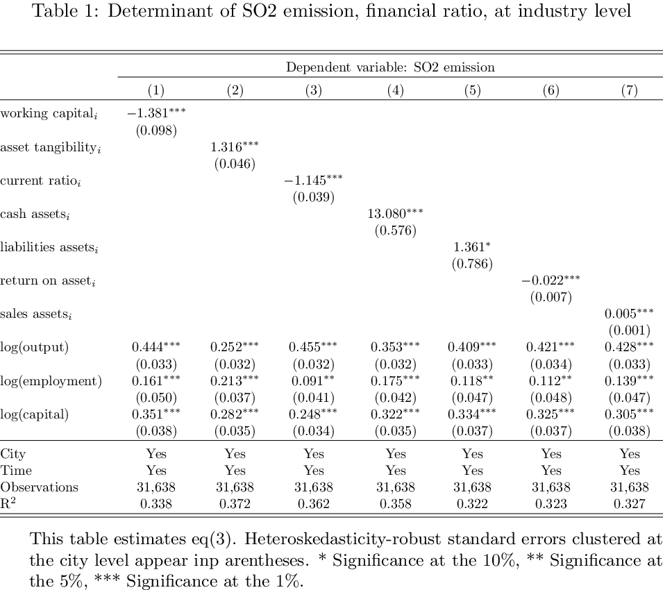

### SO2 intensity

```
'Tables_0/table_1.txt'
```

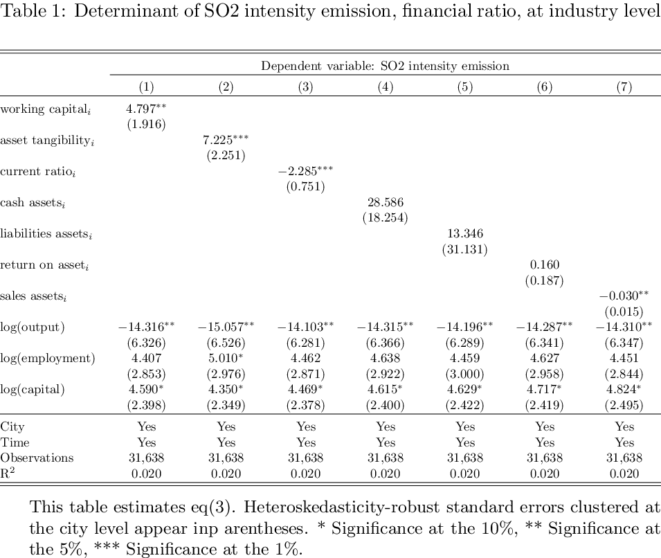

## city- Industry Level

Financial ratio are computed at the city-industry level

### SO2

```
'Tables_0/table_2.txt'
```

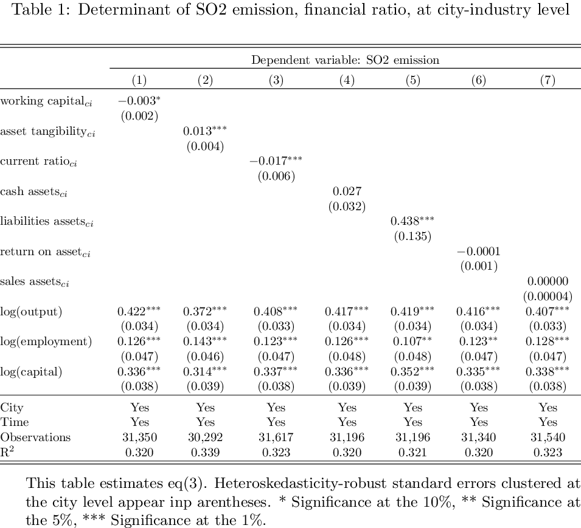

### SO2 intensity

```
'Tables_0/table_3.txt'
```

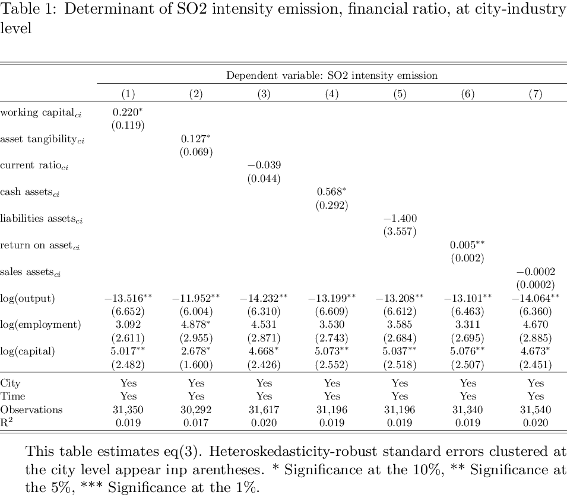

## city-Industry-year Level

Financial ratio are computed at the city-industry-year level

### SO2

```
'Tables_0/table_4.txt'
```

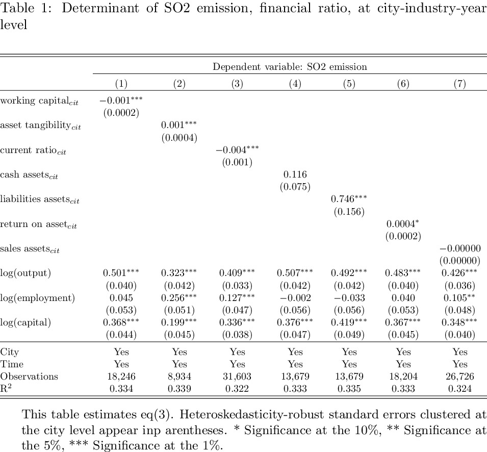

### SO2 intensity

```
'Tables_0/table_5.txt'
```

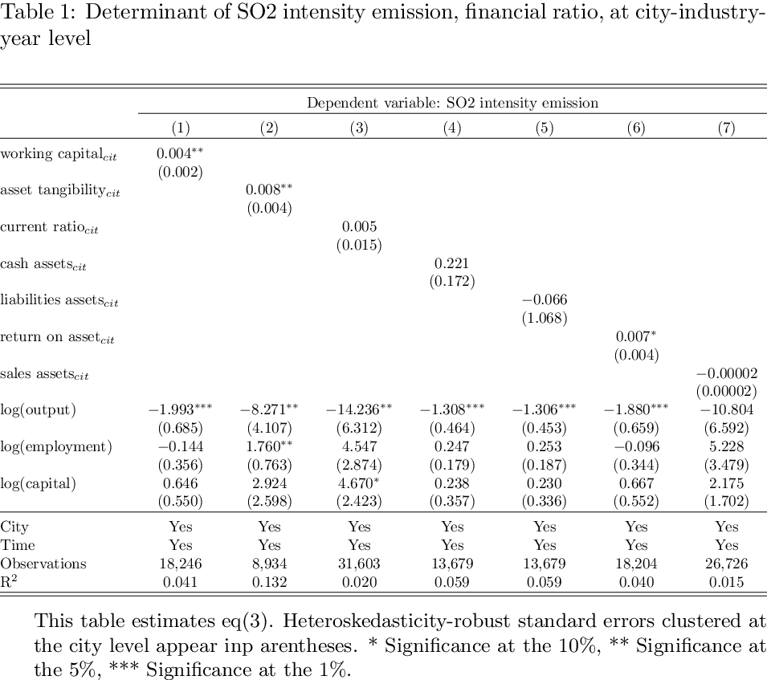

# Table 2 & 3: Baseline estimate, SO2 emission reduction, financial ratio and period

$$ \begin{aligned} \text{SO2}_{cit} &= \alpha \text{Financial ratio}_i \times \text{Period} + \gamma_{c} + \gamma_{t} + \epsilon_{cit} \end{aligned} $$

## Industry Level

Financial ratio are computed at the industry level

### SO2

```
'Tables_0/table_6.txt'
```

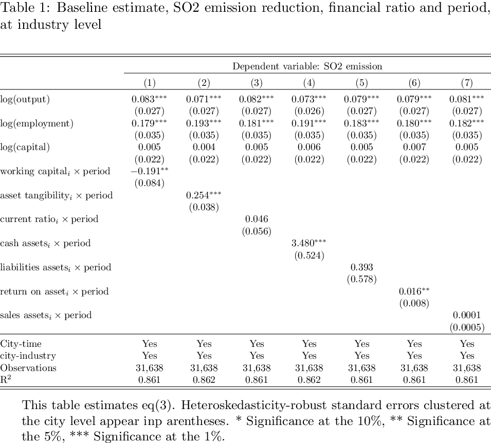

### SO2 intensity

```
'Tables_0/table_7.txt'
```

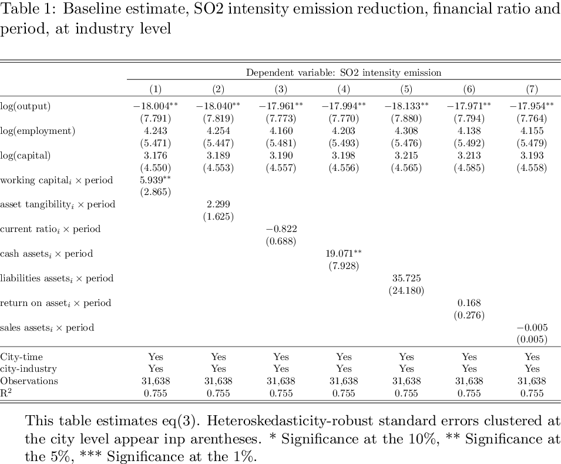

## city- Industry Level

Financial ratio are computed at the city-industry level

### SO2

```
'Tables_0/table_8.txt'
```

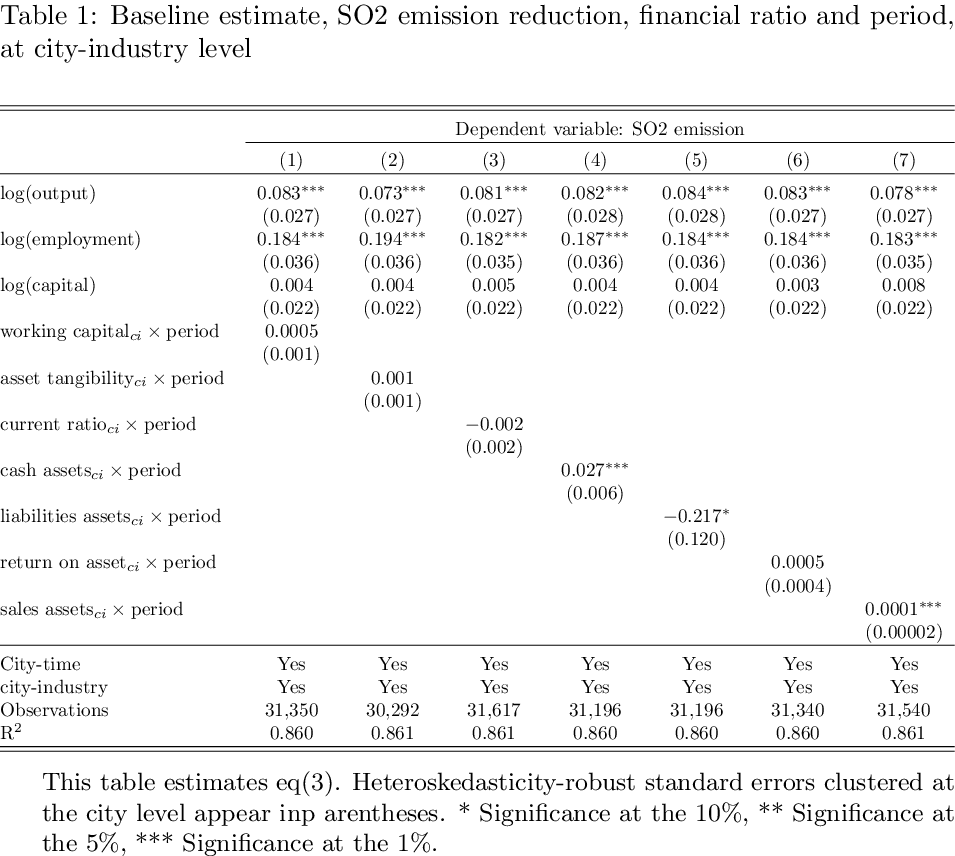

```
'Tables_0/table_9.txt'
```

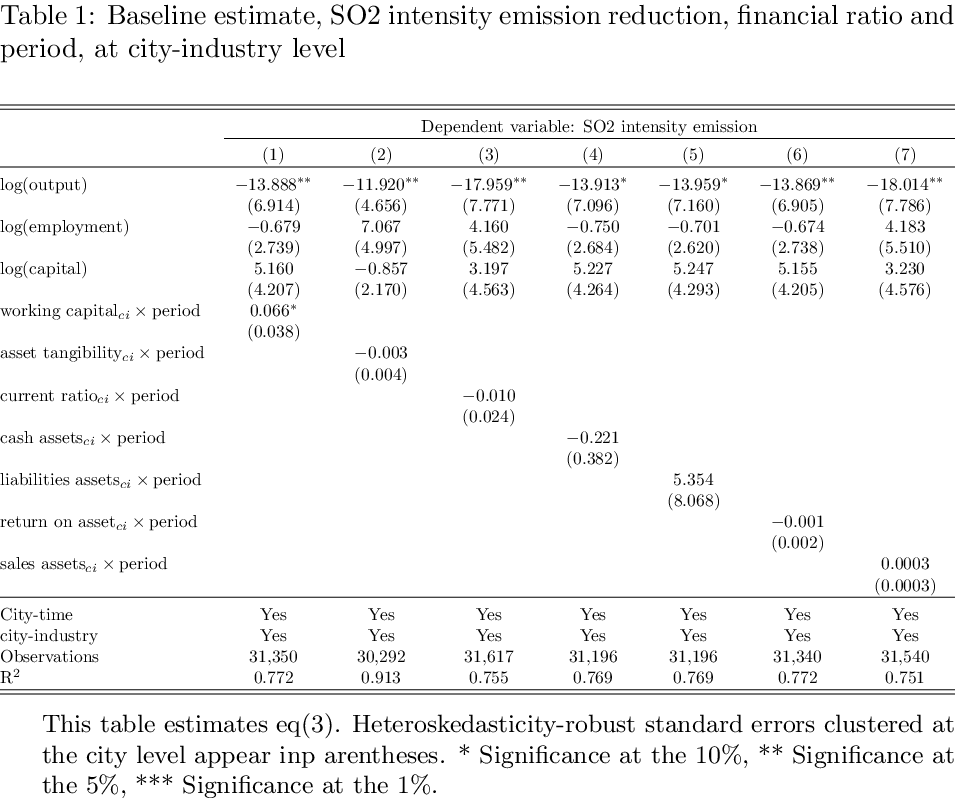

## city-Industry-year Level

Financial ratio are computed at the city-industry-year level

### SO2

```
'Tables_0/table_10.txt'
```

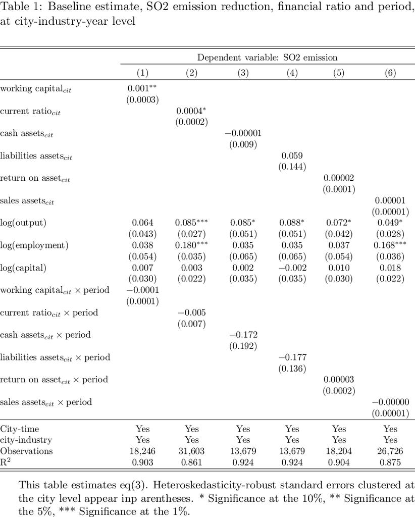

### SO2 intensity

```
'Tables_0/table_11.txt'
```

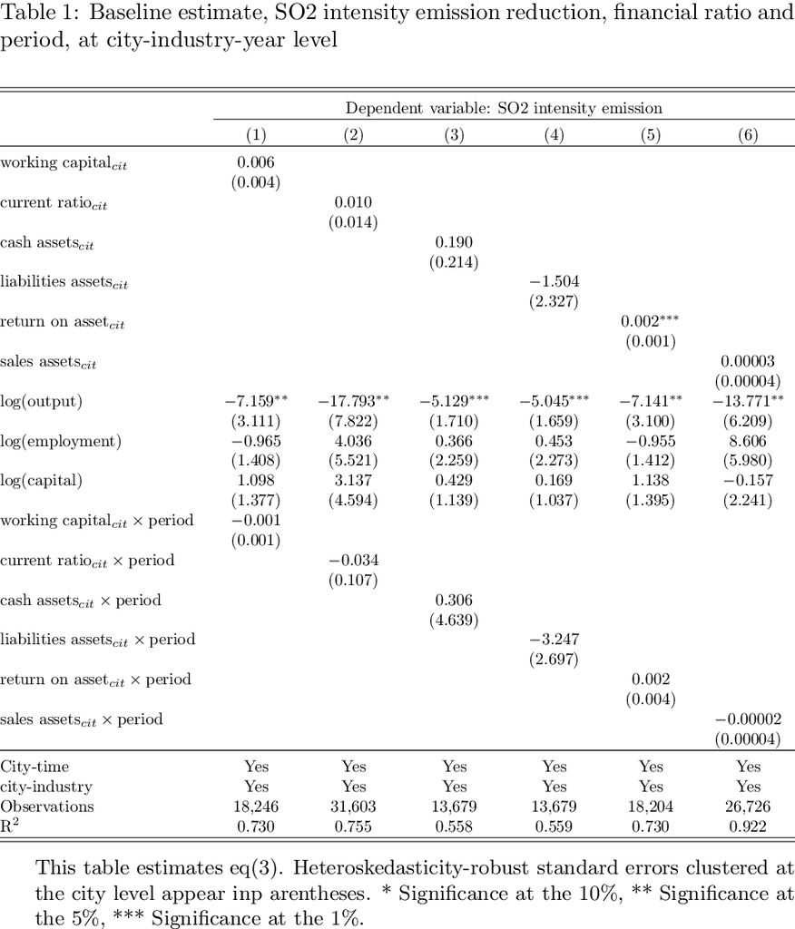

# Table 4 & 5: Baseline estimate, SO2 emission reduction, financial ratio, filter polluted & no polluted sector

$$ \begin{aligned} \text{SO2}_{cit} &= \alpha \text{Financial ratio}_i \times \text{Period} + \gamma_{c} + \gamma_{t} + \epsilon_{cit} \end{aligned} $$

## Industry Level

Financial ratio are computed at the industry level

### SO2

```
'Tables_0/table_12.txt'
```

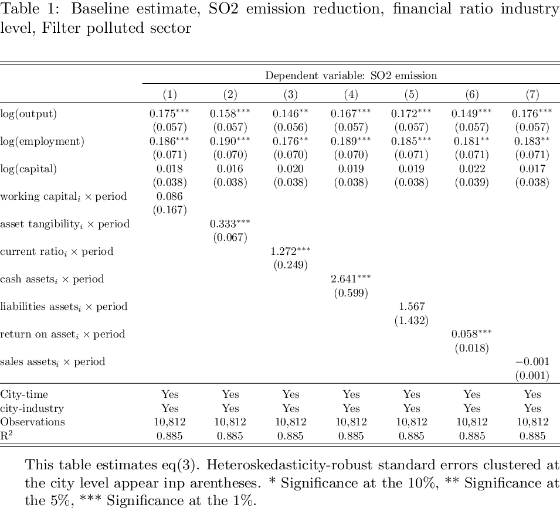

```
'Tables_0/table_13.txt'
```

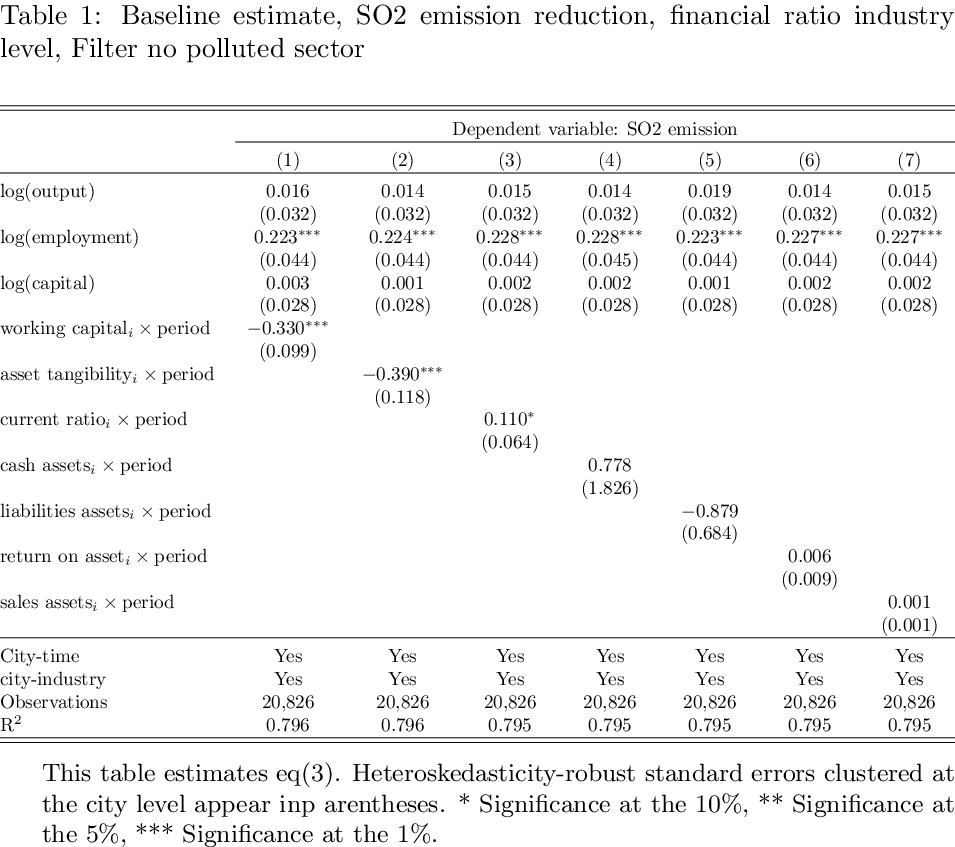

### SO2 intensity

```
'Tables_0/table_14.txt'
```

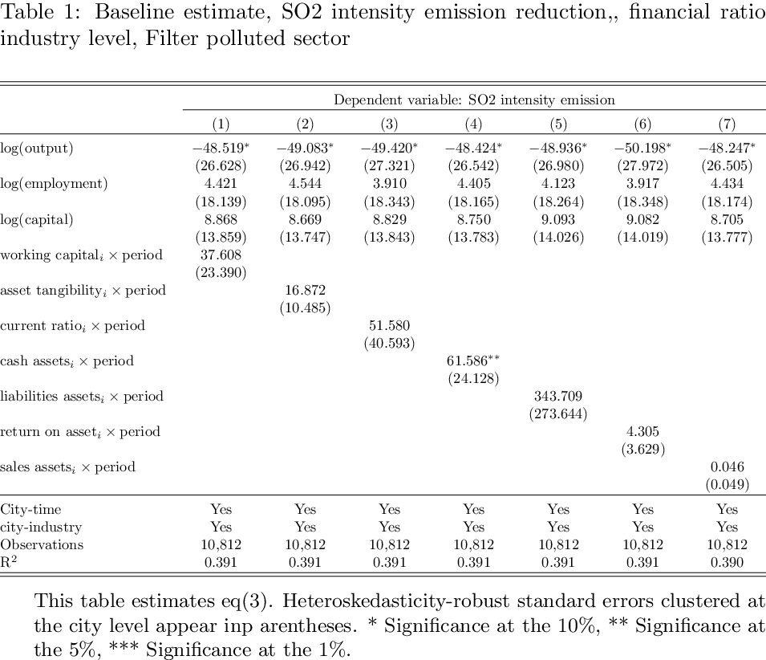

```
'Tables_0/table_15.txt'
```

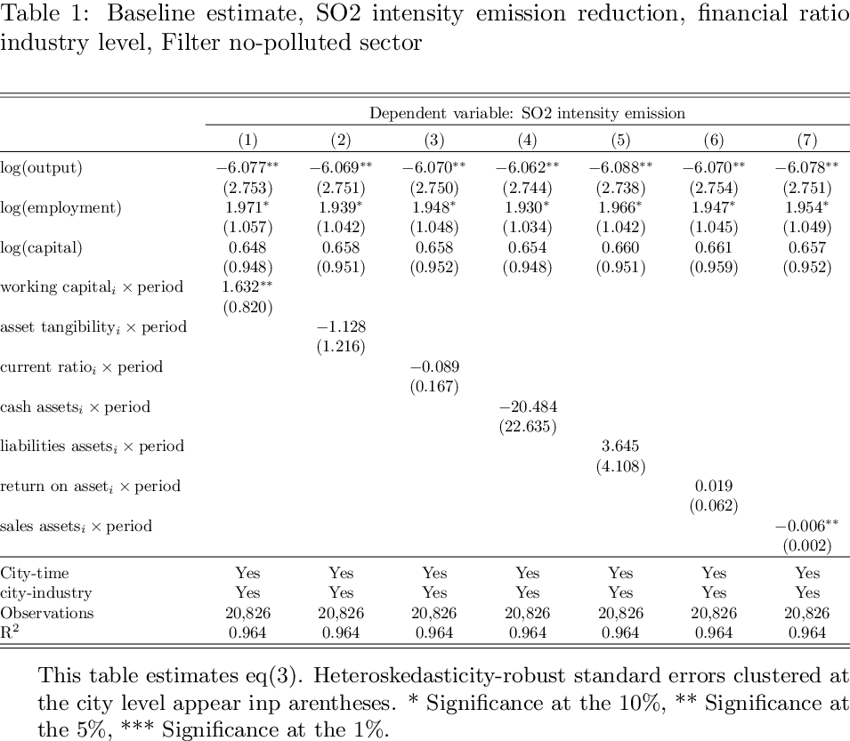

## city- Industry Level

Financial ratio are computed at the city-industry level

### SO2

```
'Tables_0/table_16.txt'
```

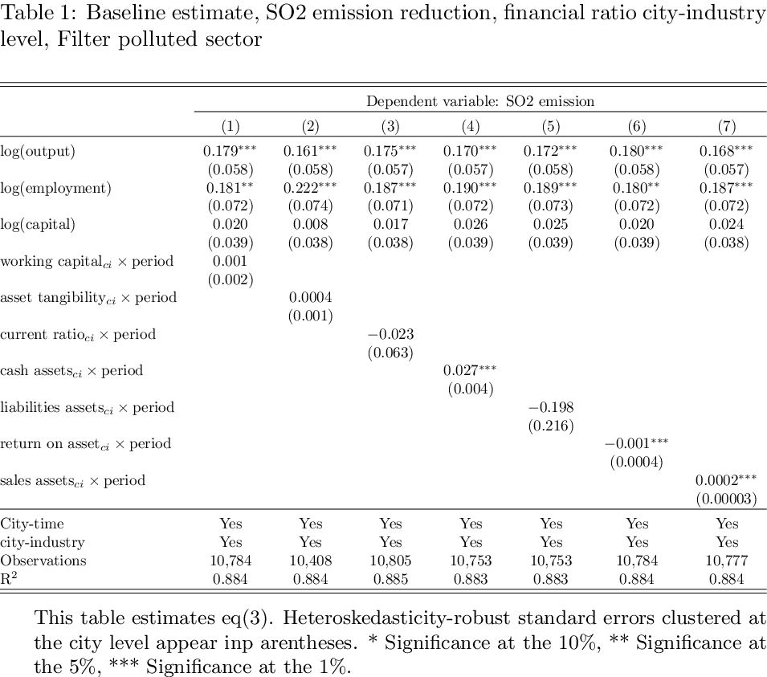

```
'Tables_0/table_17.txt'
```

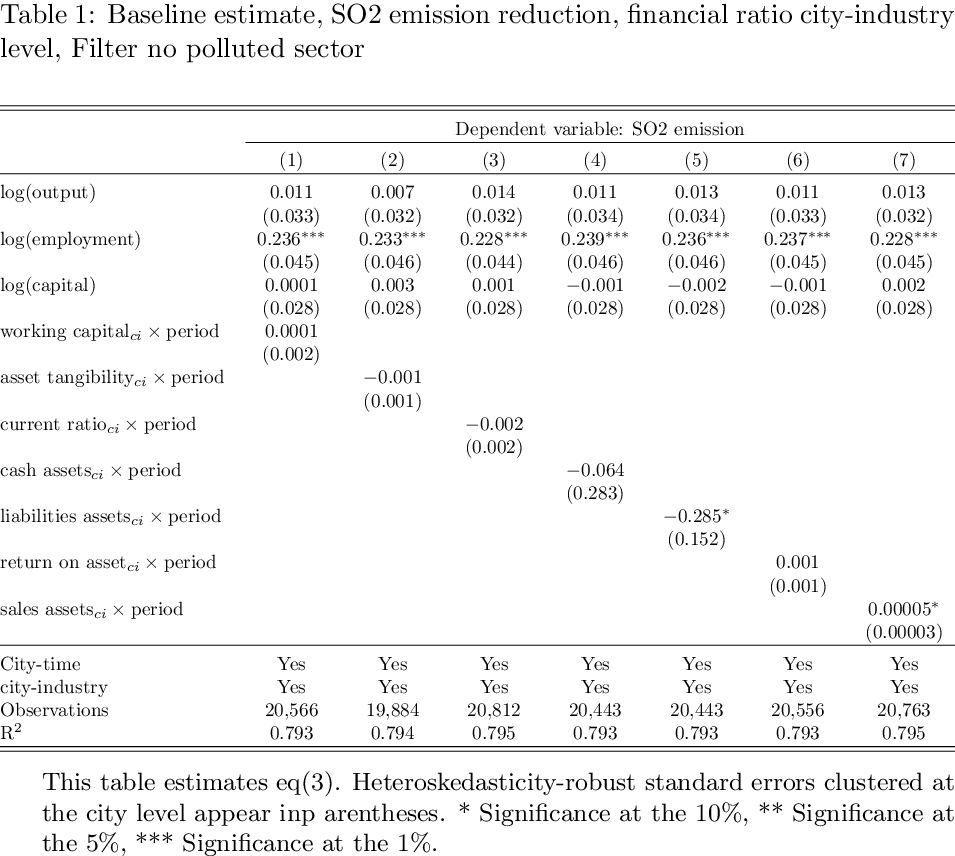

### SO2 intensity

```
'Tables_0/table_18.txt'
```

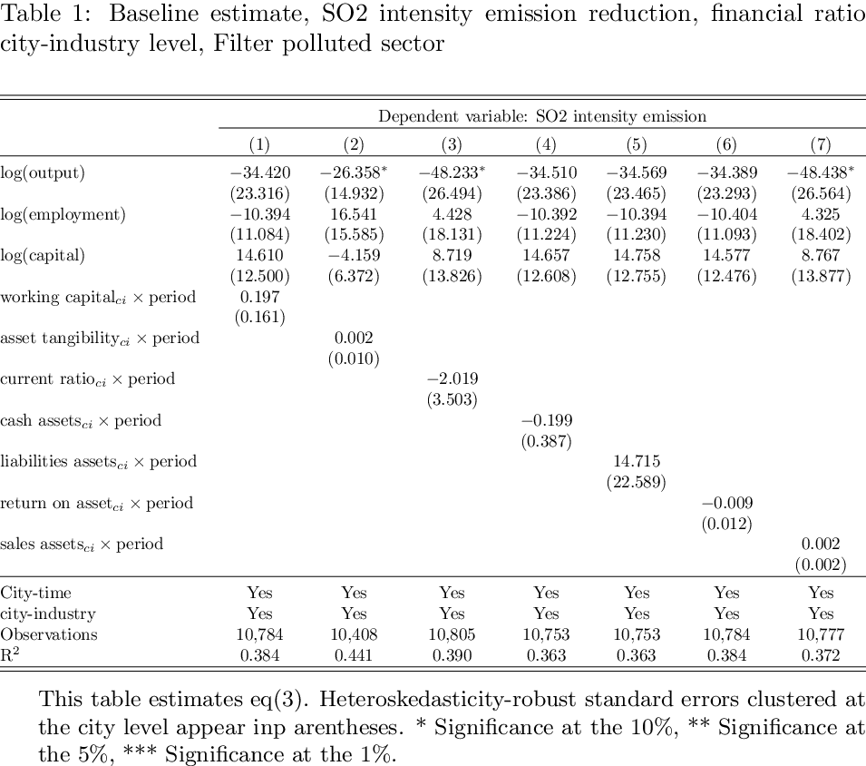

```
'Tables_0/table_19.txt'
```

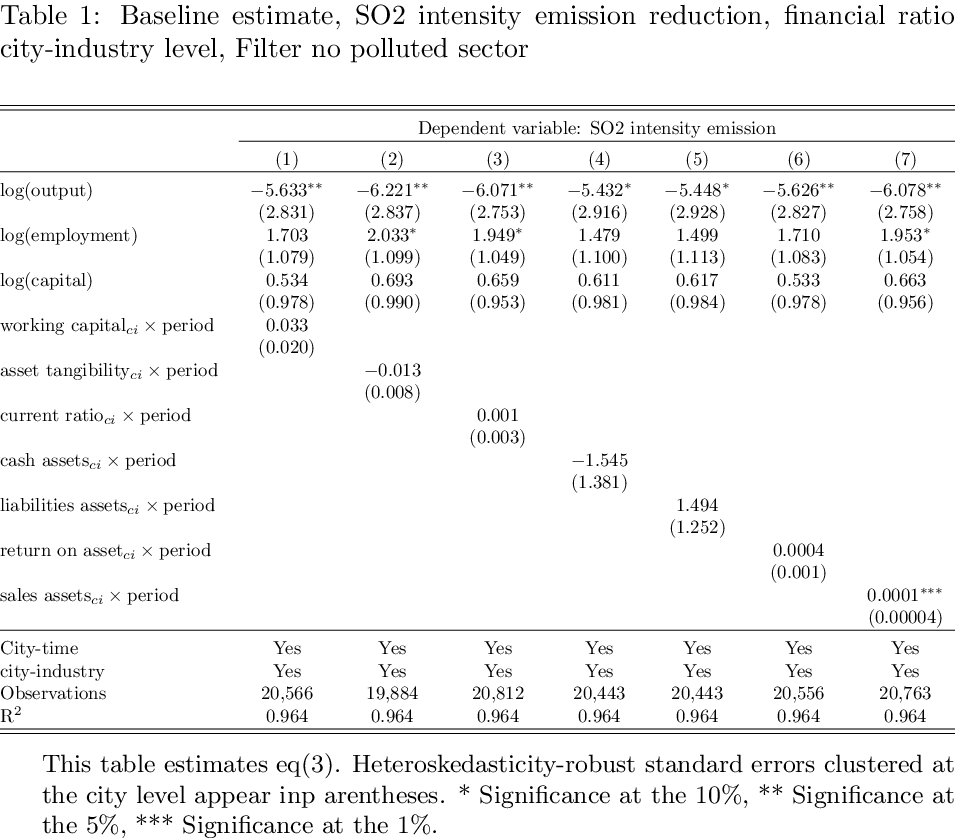

## city-Industry-year Level

Financial ratio are computed at the city-industry-year level

### SO2

```
'Tables_0/table_20.txt'
```

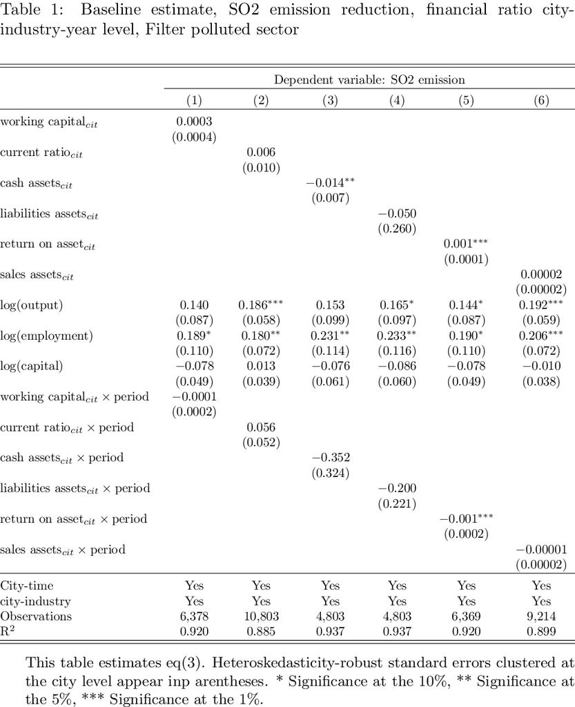

```
'Tables_0/table_21.txt'
```

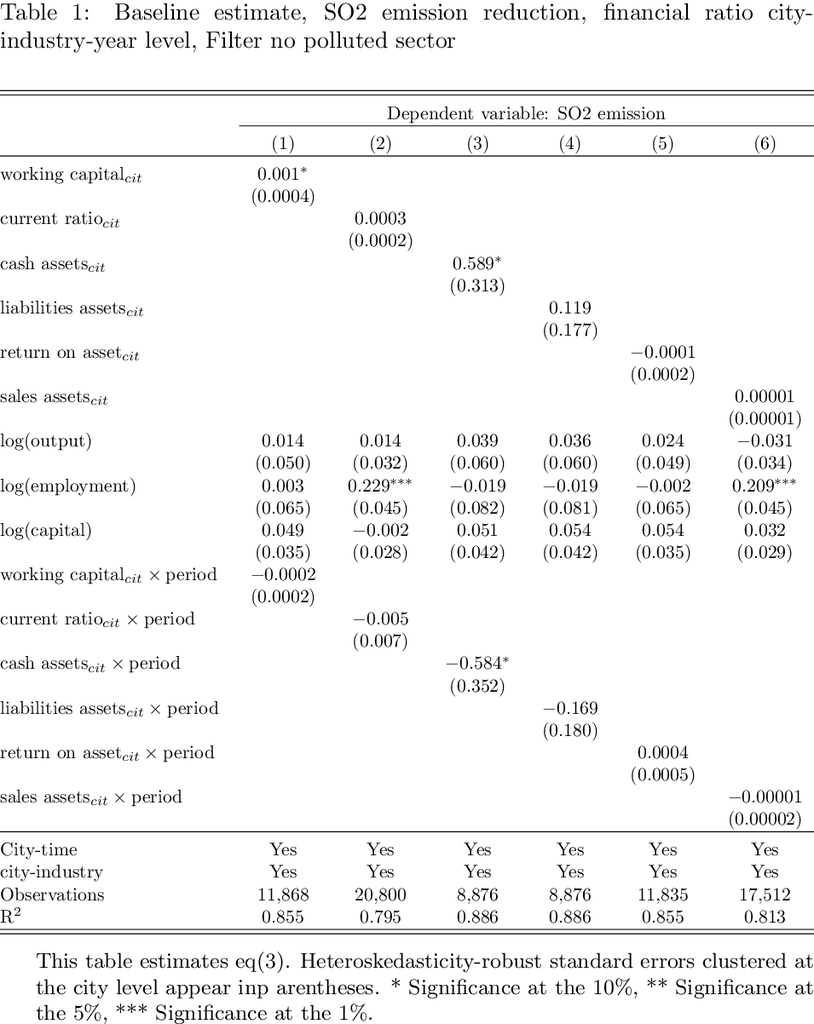

### SO2 intensity

```
'Tables_0/table_22.txt'
```

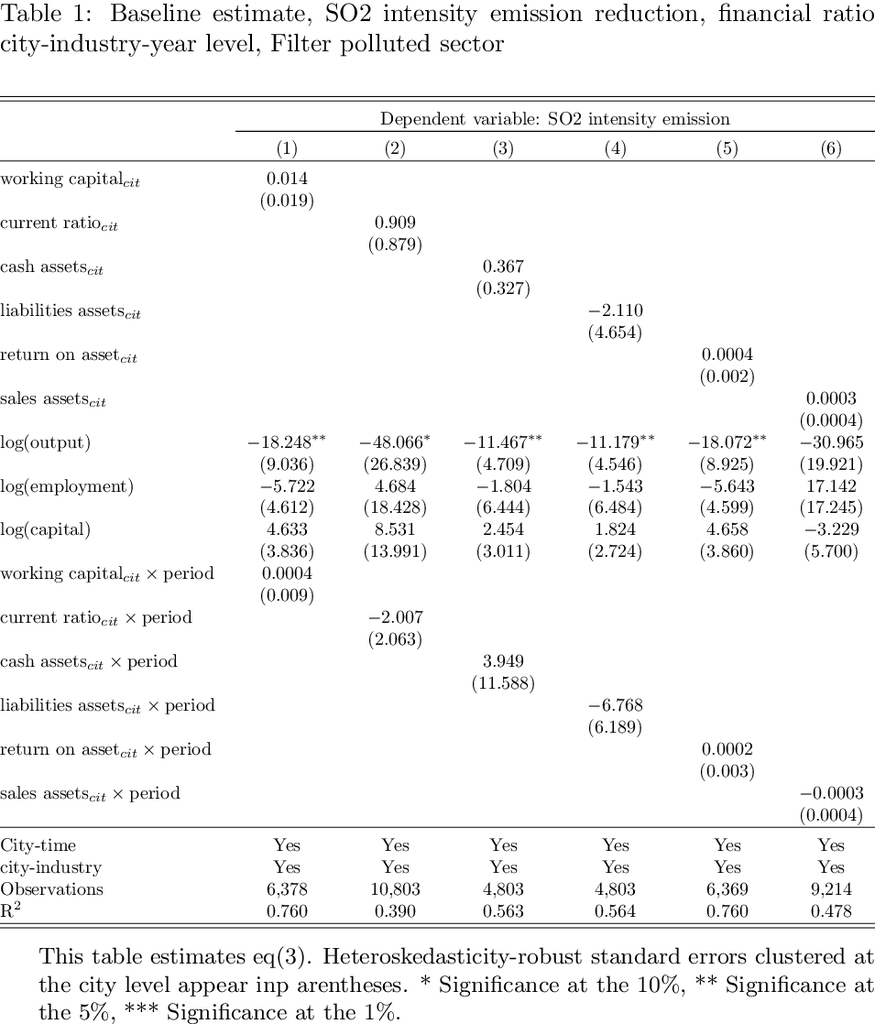

```
'Tables_0/table_23.txt'
```

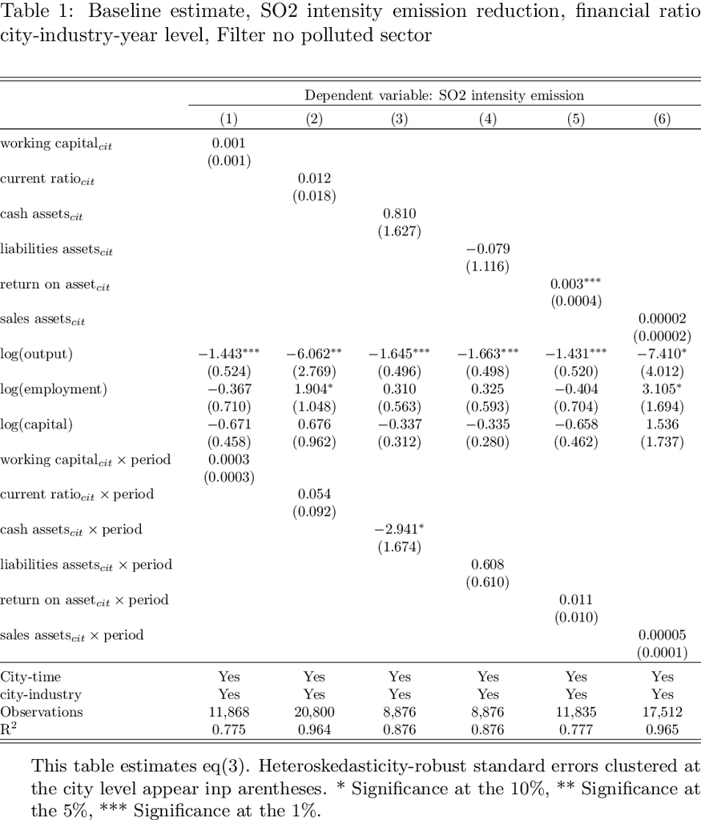

# Table 6 & 7: Baseline estimate, SO2 emission reduction, financial ratio, filter polluted & no polluted sector

## city- Industry Level

Financial ratio are computed at the city-industry level

```
'Tables_0/table_24.txt'
```

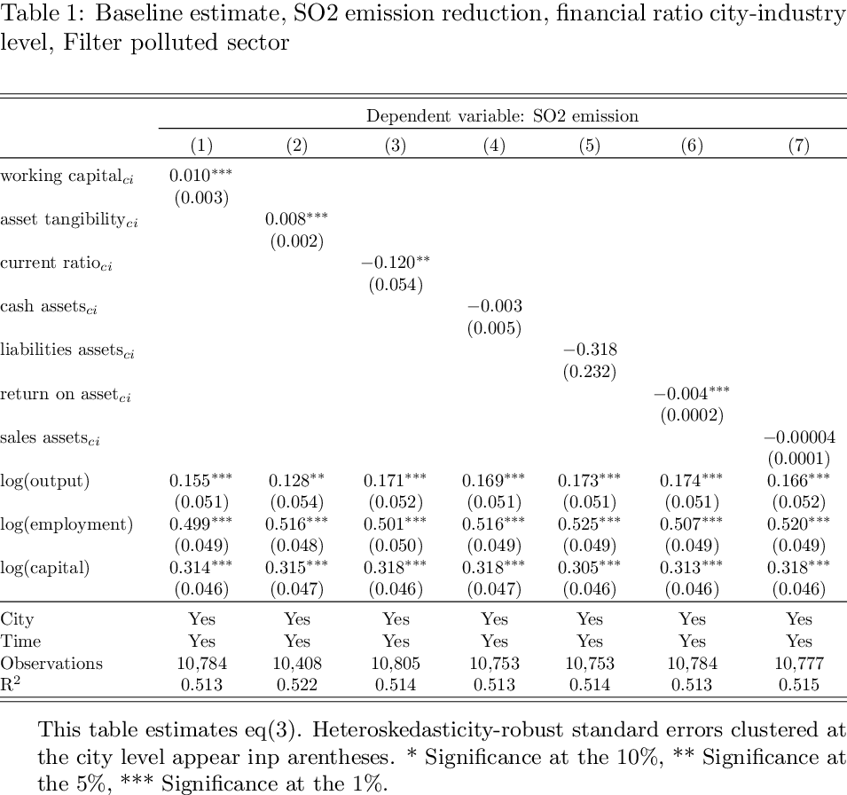

```
'Tables_0/table_25.txt'
```

[figure not shown]